# TFM: Análisis de Serie Temporal Semanal

Maria del Carmen Martínez Caro

Máster Bioestadística

### Librerías utilizadas

```r
library(readr) # leer datos
library(dplyr)
library(ggplot2) # graficar
library(forecast)
library(grid)
library(gridExtra)
library(stats) # para convertir a clase serie temporal con ts
library(tidyverse) # para agrupar bien los datos
library(cowplot) # combinación de grágicos FAC
library(urca)
```

# 1. Introducción

Los datos corresponden a registros de llamadas de intentos de suicidio recogidas por el 112 en la Comunidad Valenciana. Se disponde de 35348 observaciones; datos desde el 1 de enero de 2018 hasta el 30 de abril de 2022 (*01/01/18 - 30/04/22*).

```r
datos_validos <- datos_TFM %>%
    group_by(datos_TFM$dia) %>% # Se agrupa en función de fecha epidemiológica
    summarise(n = n())

serie <- ts(datos_validos$n, start = c(1, 1), # 1 Enero de 2018 (lunes de la primera semana)
            end = c(226, 6), # 30 Abril de 2022 (sabado de la semana 226)
            freq = 7) # 7 días tiene cada semana
```

# 2. Descriptiva

La figura 2.1 muestra la evolución de la serie diaria, la cual muestra una **tendencia** creciente en el número de llamadas a partir de la semana 171 aproximadamente.

Podría decirse que se aprecia también una posible componente estacional relacionada con los meses. La amplitud estacional parece mantenerse en el tiempo pero al aumentar el número de llamadas en el último año también parece aumentar dicha amplitud estacional.

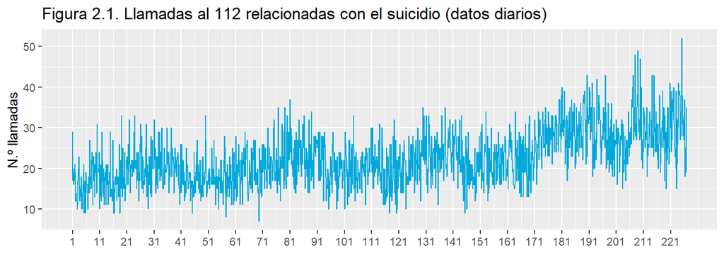

```r
autoplot(serie,
         xlab = "",
         ylab = "N.º llamadas",
         main = "Figura 2.1. Llamadas al 112 relacionadas con el suicidio (datos diarios)",
         col = "#01A9DB") +
    scale_x_continuous(breaks = seq(1, 226, 10))
```

Se va a comprobar el tipo de esquema para saber la forma en la que se relacionan las componentes de la serie temporal.

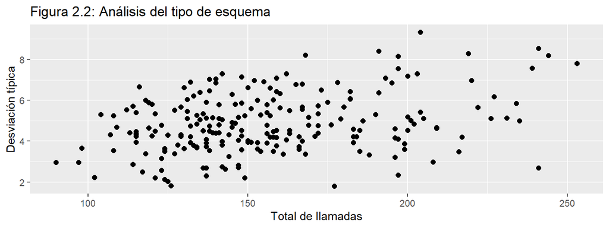

```r
CasosSemanal = aggregate(serie, FUN = sum) # número de llamadas por semana
DesviacionSemanal = aggregate(serie, FUN = sd)

ggplot() +
  geom_point(aes(x = CasosSemanal, y = DesviacionSemanal), size = 2) +
xlab("Total de llamadas") +
ylab("Desviación típica") +
ggtitle("Figura 2.2: Análisis del tipo de esquema")
```

En el gráfico cada punto representa una semana donde la coordenada *X* es el número de llamadas y la coordenada *Y* la desviación típica del número de llamadas para los días de esa semana.

No hay un patrón perfectamente diferenciable pero parece ser **creciente**. Por tanto las semanas con mayor número de llamadas se corresponde con una mayor variabilidad intra-semanal. De modo que se podría considerar un **esquema multiplicativo** en la serie.

Observando dicho gráfico, no hay un patrón perfectamente diferenciable pero parece ser creciente. Por tanto las semanas con mayor número de llamadas corresponderá a una mayor variabilidad intra-semanal. De modo que se considera que la serie presenta un esquema multiplicativo.

## 2.1. Tendencia

Si se agregan los datos en números de llamadas por semana, se pueden identificar mejor los posibles cambios de tendencia.

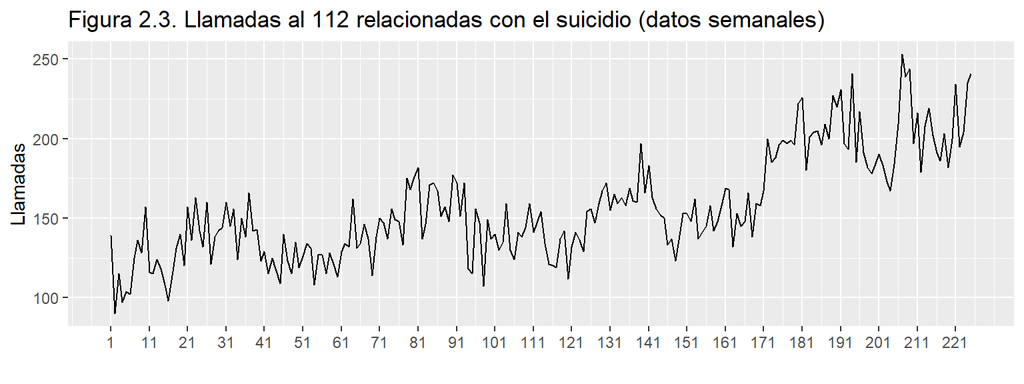

```r
autoplot(aggregate(serie, FUN = sum), # se agrega los datos de cada periodo estacional completo
           # (se podría utilizar mean en vez de sum)
xlab = "",
ylab = "Llamadas",
main = "Figura 2.3. Llamadas al 112 relacionadas con el suicidio (datos semanales)") +
scale_x_continuous(breaks = seq(1, 226, 10))
```

## 2.2. Estacionalidad

### **Análisis gráfico de la estacionalidad**

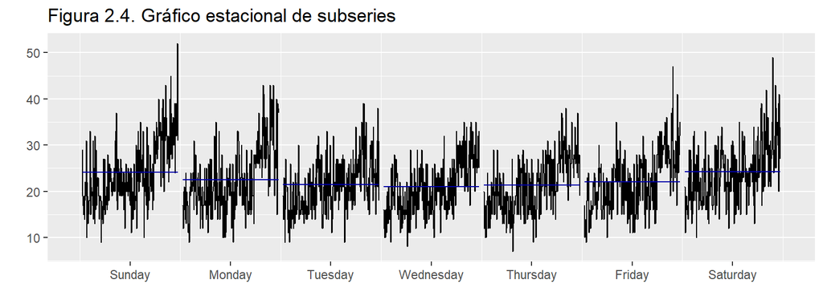

```r
ggsubseriesplot(serie,
                polar = TRUE,
                xlab = "",
                ylab = "",
                main = "Figura 2.4. Gráfico estacional de subseries") +
                guides(colour = FALSE)
```

Respecto a la estacionalidad, el tiempo claramente ha influido; lo que no está claro todavía es si hay cierta influencia de las estaciones o son otras causas el motivo de ello.

### **Análisis numérico de la estacionalidad**

Anteriormente, en la figura 2.2 se ha concluido que la serie presenta un esquema multiplicativo; por tanto, para obtener la componente estacional se han seguido los siguientes comandos:

$$Componentes estacional =
\frac{\sum_{t=1}^{n} \frac{Y_t}{\overline{Y}} }{n_i}$$

```r
# Esquema multiplicativo
componenteEstacional <- tapply(serie/mean(serie),
                               cycle(serie),
                               FUN = mean)
round(componenteEstacional, 2)
```

```
##    1    2    3    4    5    6    7
## 1.08 1.01 0.96 0.94 0.95 0.98 1.08
```

Los valores indican que tanto en los lunes como en los domingos hay un 8% más de llamadas respecto de la media semanal y los jueves un 6% menos.

## 2.3. Descomposición de la serie

Después de realizar la descripción de las principales componentes de la serie, la tendencia y la estacionalidad, se va a descomponer la serie. Aunque sea de forma gráfica se busca principalmente analizar el error para tener una idea de la importancia que tendrá la componente de intervención.

Debido a que la serie temporal se a detectado con esquema multiplicativo se va a utilizar el método de medias móviles para la descomposición.

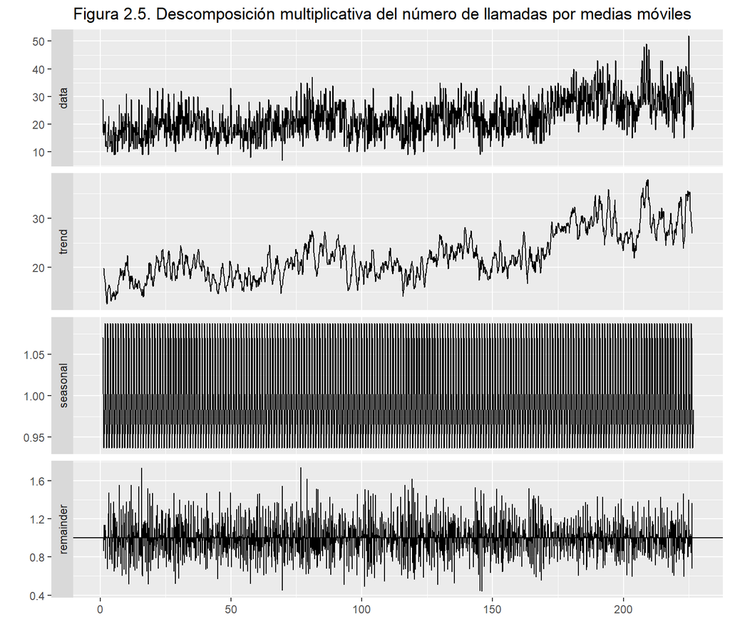

```r
# Descomposición multiplicativa (DesMul)
llamadasDesMul <- decompose(serie, type = "mult")
autoplot(llamadasDesMul,
         xlab = "",
         main = "Figura 2.5. Descomposición multiplicativa del número de llamadas por medias móviles")
```

```r
llamadasDesMul$figur
```

```
## [1] 1.0705273 1.0024694 0.9655126 0.9369746 0.9537448 0.9830544 1.0877171
```

```r
round(llamadasDesMul$figure, 2)
```

```
## [1] 1.07 1.00 0.97 0.94 0.95 0.98 1.09
```

La **tendencia** obtenida tras la descomposición confirma lo ya observado de que hay una tendencia creciente, pronunciada al final, en el número de llamadas.

También se aprecian claramente varios valores atípicos en el **residuo**.

Respecto de la **componente estacional**, al ser tantos datos, visualmente no se puede identificar bien, por tanto se plantea la opción de posteriormente analizar la serie temporal separando los datos por año. En cambio numéricamente se puede ver que tanto en los lunes como en los domingos hay un 8% más de llamadas respecto de la media semanal y los jueves un 6% menos.

### **Análisis del residuo del método de descomposición**

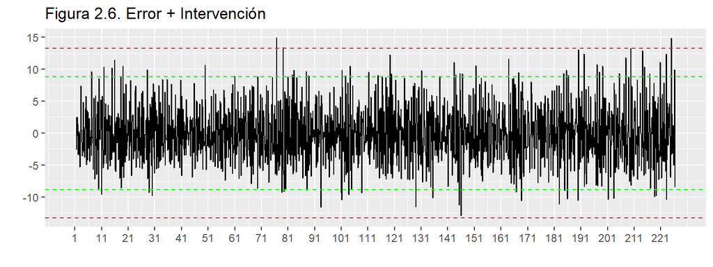

```r
# Restar a la serie original la serie estimada,
# obtenida como producto de la tendencia por la estacionalidad:
# R_t = y_t - (T_t * S_t)
error <- serie - trendcycle(llamadasDesMul) * seasonal(llamadasDesMul)

sderror <-sd(error, na.rm = TRUE)

autoplot(error,
         xlab = "",
         ylab = "",
         main = "Figura 2.6. Error + Intervención",
         colour = "black") +
  geom_hline(yintercept = c(3, 2, -2, -3)*sderror,
             colour = c("red", "green", "green", "red"),
             lty = 2) +
  scale_x_continuous(breaks = seq(1, 226, 10))
```

```r
time(error)[abs(error) > 3*sderror]
```

```
##  [1]        NA        NA        NA  76.71429  79.14286 209.71429 225.00000
##  [8]        NA        NA        NA
```

La figura 2.6 muestra el error de la descomposición y los intervalos de confianza (IC) al 95% en verde y al 99.7% en rojo.

Se observan 4 valores claramente extremos que cruzan el IC(99.7%) por la parte superior de la gráfica.

# 3. Alisado exponencial

Primero se va a analizar la capacidad predictiva de los métodos de Alisado exponencial sobre la serie. Se ajustará entonces el mejor modelo de alisado para estimar los criterios de calidad para el ajuste y la predicción extra-muestral según el horizonte temporal.

# 3.1. Análisis de la serie

### **Estimación e interpretación**

Aplicando la metodología de alisado exponencial a la serie, si se estima el modelo sin ninguna restricción la función *ets* indica como modelo óptimo ETS(M,N,A). El modelo estimado tiene error multiplicativo, sin tendencia y estacionalidad aditiva:

$$y_{t+1} = l_t + s_{t+1-m}$$

siendo *t* el periodo; *l* el nivel; *s* la estacionalidad; *m* el orden estacional

(o sería más correcto?:)
$$y_{t} = S_{t-m}
+ \epsilon_{t} \cdot S_{t-m}$$
Donde:

$y_t$ es el valor observado en el tiempo $t$ $S_{t-m}$ es la componente estacional en el tiempo $t$ $\epsilon_{t}$ es el término de error en el tiempo $t$ $m$ es la periodicidad de la estacionalidad

```r
serieETS <- ets(serie)
summary(serieETS)
```

```
## ETS(M,N,A)
##
## Call:
##  ets(y = serie)
##
##   Smoothing parameters:
##     alpha = 0.0689
##     gamma = 1e-04
##
##   Initial states:
##     l = 17.3654
##     s = 1.8622 -0.2551 -1.1397 -1.2957 -0.39 0.0177
##            1.2007
##
##   sigma:  0.2337
##
##      AIC     AICc      BIC
## 16808.49 16808.63 16862.14
##
## Training set error measures:
##                     ME     RMSE      MAE       MPE     MAPE      MASE
## Training set 0.1198591 5.113185 4.064901 -5.171422 20.05897 0.7232005
##                    ACF1
## Training set 0.05935273
```

La sección “Smoothing parameters” muestra los parámetros de suavizado del modelo ajustado.

La sección “Initial states” los valores iniciales estimados para la componente de nivel y la componente estacional del modelo en este caso

La sección “sigma” muestra el valor estimado de la desviación estándar del ruido (error) del modelo.

Según el método utilizado, los valores óptimos para los parámetros son $\alpha = 0.07$, $\gamma = 1*10^{-4}$, $l_0 = 17.37$

El valor de $\alpha = 0.07$ indica que el nivel de la serie ha ido variando muy lentamente en el tiempo.

El valor de $\gamma = 1*10^{-4}$ indica que la estacionalidad modifica su valor muy lentamente; es decir hay estacionalidad permanece constante en el tiempo.

El valor de arranque óptimo es $l_0 = 17.37$.

Los últimos valores estimados del nivel y la estacionalidad, permiten ver gráficamente la componente estacional:

```r
TT <- nrow(serieETS$states)
round(serieETS$states[TT,],2)
```

```
##     l    s1    s2    s3    s4    s5    s6    s7
## 30.41 -0.25 -1.13 -1.29 -0.40  0.02  1.22  1.86
```

```r
componenteEstacional <- serieETS$states[TT, 8:2]
# (El 8 corresponde a la l y las 7 s)
componenteEstacional
```

```
##          s7          s6          s5          s4          s3          s2
##  1.86462883  1.21621707  0.02308759 -0.40033204 -1.29481226 -1.13479799
##          s1
## -0.25499642
```

```r
dias<-c("lunes", "martes", "miércoles", "jueves", "viernes", "sábado", "domingo")
names(componenteEstacional) <- dias
round(componenteEstacional, 2)
```

```
##     lunes    martes miércoles    jueves   viernes    sábado   domingo
##      1.86      1.22      0.02     -0.40     -1.29     -1.13     -0.25
```

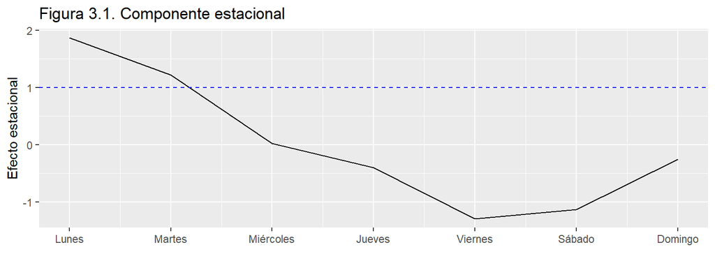

```r
ggplot() +
  geom_line(aes(x = 1:7, y = componenteEstacional)) +
  geom_hline(yintercept = 1, colour = "blue", lty = 2) +
  ggtitle("Figura 3.1. Componente estacional") +
  xlab("") +
  ylab("Efecto estacional") +
  scale_x_continuous(breaks = 1:7,
                     labels = c("Lunes", "Martes", "Miércoles", "Jueves", "Viernes", "Sábado", "Domingo"))
```

El nivel de llamadas del 30 de abril de 2022 (última observación) es de 30 casos y sin pendiente.

### **Predicción**

```r
serieETS.prediccion <- forecast(serieETS, h = 35, level = 95) # predicción máxima de 35 observaciones (35 semanas o 8 meses aprox). Con intervalos de confianza al 95%
serieETS.prediccion
```

```
##          Point Forecast    Lo 95    Hi 95
## 226.8571       32.27700 17.49251 47.06150
## 227.0000       31.62859 17.10344 46.15374
## 227.1429       30.43546 16.41787 44.45306
## 227.2857       30.01204 16.15220 43.87189
## 227.4286       29.11756 15.62891 42.60622
## 227.5714       29.27758 15.68366 42.87150
## 227.7143       30.15738 16.13349 44.18127
## 227.8571       32.27700 17.26399 47.29002
## 228.0000       31.62859 16.87085 46.38633
## 228.1429       30.43546 16.17694 44.69399
## 228.2857       30.01204 15.90852 44.11557
## 228.4286       29.11756 15.37858 42.85655
## 228.5714       29.27758 15.43516 43.12000
## 228.7143       30.15738 15.89241 44.42235
## 228.8571       32.27700 17.03850 47.51551
## 229.0000       31.62859 16.64146 46.61572
## 229.1429       30.43546 15.93959 44.93134
## 229.2857       30.01204 15.66855 44.35554
## 229.4286       29.11756 15.13228 43.10285
## 229.5714       29.27758 15.19061 43.36455
## 229.7143       30.15738 15.65490 44.65986
## 229.8571       32.27700 16.81588 47.73812
## 230.0000       31.62859 16.41512 46.84206
## 230.1429       30.43546 15.70564 45.16529
## 230.2857       30.01204 15.43210 44.59199
## 230.4286       29.11756 14.88982 43.34531
## 230.5714       29.27758 14.94979 43.60536
## 230.7143       30.15738 15.42080 44.89396
## 230.8571       32.27700 16.59604 47.95797
## 231.0000       31.62859 16.19170 47.06549
## 231.1429       30.43546 15.47493 45.39599
## 231.2857       30.01204 15.19901 44.82508
## 231.4286       29.11756 14.65098 43.58414
## 231.5714       29.27758 14.71254 43.84262
## 231.7143       30.15738 15.18995 45.12481
```

[figure not shown]

```r
autoplot(serieETS.prediccion,
         xlab = "",
         ylab = "Llamadas",
         main = "Figura 3.2. Llamadas y predicción de 35 semanas")
```

```r
# Intentando hacer la predicción del resto del último año que no tenemos sería 35 semanas aprox

# Crear un objeto de fecha para el 30 de abril de 2022
fecha <- as.Date("2022-04-30")

# Obtener el día de la semana para la fecha
weekdays(fecha)
```

```
## [1] "sábado"
```

### **Análisis del error**

Se va a analizar el residuo del modelo, estimado aditivamente.

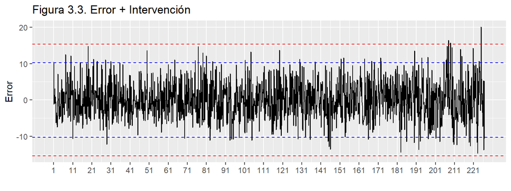

```r
error <- residuals(serieETS, type = "response")
sderror <- sd(error)

autoplot(error,
         xlab = "",
         ylab = "Error",
         main = "Figura 3.3. Error + Intervención",
         colour = "black") +
  geom_hline(yintercept = c(-3, -2, 2, 3)*sderror,
             colour = c("red", "blue", "blue", "red"), lty = 2) +
  scale_x_continuous(breaks = seq(1, 226, 10))
```

```r
# Número de semanas con datos anómalos:
sum(abs(error) > 3 * sderror)
```

```
## [1] 3
```

```r
sum(abs(error) > 2.5 * sderror)
```

```
## [1] 20
```

```r
time(error)[abs(error) > 3*sderror]
```

```
## [1] 207.8571 208.8571 225.0000
```

```r
# Domingo de la semana 85 (22 de septiembre de 2019); domingo de la semana 208 (14 de abril de 2022), lunes de la semana 225 (16 de enero de 2023)

time(error)[abs(error) > 2*sderror]
```

```
##  [1]   1.000000   7.285714  10.000000  11.000000  14.857143  19.000000
##  [7]  21.857143  23.571429  23.857143  28.142857  28.857143  31.000000
## [13]  49.857143  64.428571  69.571429  75.142857  76.714286  79.142857
## [19]  81.000000  82.857143  84.285714  93.285714  94.285714  95.142857
## [25]  98.142857 101.285714 104.285714 104.857143 119.285714 129.000000
## [31] 129.857143 130.142857 132.857143 135.428571 138.000000 144.714286
## [37] 145.285714 146.000000 151.571429 153.000000 163.857143 165.857143
## [43] 167.571429 169.000000 172.285714 172.428571 182.857143 185.857143
## [49] 189.857143 190.142857 192.285714 193.000000 193.857143 197.000000
## [55] 197.285714 201.285714 203.285714 205.428571 206.714286 207.000000
## [61] 207.142857 207.857143 208.857143 209.000000 209.714286 210.285714
## [67] 210.714286 212.285714 214.142857 214.857143 218.714286 219.285714
## [73] 220.714286 222.857143 223.142857 223.857143 225.000000 226.285714
## [79] 226.571429
```

Se aprecian tres valores extremos, al final de los datos, en las que el residuo supera las tres desviaciontes típicas porque el número de llamadas fue muy superior al estimado por el modelo. Además hay otros residuos que superan las 2.5 desviaciones típicas que son susceptibles de ser considerados intervención.

# 3.2. Otras alternativas

Si se tienen en cuenta métodos alternativos como la transformación logarítmica y la insesgada:

| **Id** | **Transformación** | **Modelo** | **Método estimación** |
| --- | --- | --- | --- |
| 1 | Ninguna | MNA | Máxima verosimilitud |
| 2 | Ninguna | MNA | mínimo error en previsiones a 2 periodos vista |
| 3 | Logaritmo | AAA | Máxima verosimilitud |
| 4 | Logaritmo | AAA | mínimo error en previsiones a 2 periodos vista |

630 son 90 semanas (aproximádamente el 40% de los datos).

```r
ets(serie)$method # ETS(M, N, A)
```

```
## [1] "ETS(M,N,A)"
```

```r
ets(serie, lambda = 0)$method # Serie transformada (transformación logarítmica)
```

```
## [1] "ETS(A,Ad,A)"
```

```r
# El comando ets(serie, lambda = 0) ajusta un modelo ETS con parámetro de suavizado de Box-Cox fijo en 0, es decir, sin transformación de Box-Cox en los datos.
  # ETS(A, Ad, A)
ets(log(serie))$method
```

```
## [1] "ETS(A,Ad,A)"
```

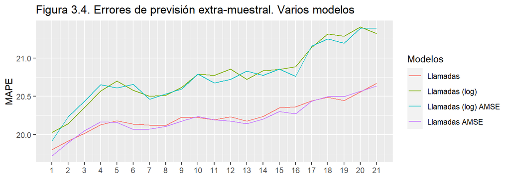

```r
#- Ajuste por alisado usando otros criterios de ajuste
k <- 630 # Puedo utilizar múltiples de las 7 semanas (entrenamiento)
h <- 21 # Pronóstico de 7 semanas (prueba)
TT <- length(serie)
s <- TT - k - h # (periodo de ajuste)

mapeAlisado1 <- matrix(NA, s + 1, h)
mapeAlisado2 <- matrix(NA, s + 1, h)
mapeAlisado3 <- matrix(NA, s + 1, h)
mapeAlisado4 <- matrix(NA, s + 1, h)
mapeAlisado5 <- matrix(NA, s + 1, h)
mapeAlisado6 <- matrix(NA, s + 1, h)

for (i in 0:s) {
  train.set <- subset(serie, start = i + 1, end = i + k)
  test.set <-  subset(serie, start = i + k + 1, end = i + k + h)

  fit <- ets(train.set, model = "MNA", damped = FALSE)
  fcast<-forecast(fit, h = h)
  mapeAlisado1[i + 1,] <- 100*abs(test.set - fcast$mean)/test.set

  fit <- ets(train.set, model = "MNA", damped = FALSE, opt.crit = "amse", nmse = 2)
  fcast<-forecast(fit, h = h)
  mapeAlisado2[i + 1,] <- 100*abs(test.set - fcast$mean)/test.set

  fit <- ets(train.set, model = "AAA", lambda = 0, biasadj = TRUE, damped = FALSE)
  fcast<-forecast(fit, h = h, biasadj = TRUE)
  mapeAlisado3[i + 1,] <- 100*abs(test.set - fcast$mean)/test.set

  fit <- ets(train.set, model = "AAA", lambda = 0, biasadj = TRUE, damped = FALSE,  opt.crit = "amse", nmse = 2)
  fcast<-forecast(fit, h = h, biasadj = TRUE)
  mapeAlisado4[i + 1,] <- 100*abs(test.set - fcast$mean)/test.set

}
  # biasadj = TRUE permite ajustar una corrección de sesgo a los pronósticos basado en la información de la muestra de entrenamiento
  # damped = FALSE indica que el modelo de tendencia no está amortiguado (es decir, la tendencia no disminuye en magnitud a medida que aumenta el horizonte de pronóstico).
  # opt.crit = "amse" especifica que se utilice el criterio de selección de modelo "AMSE" (Error Cuadrático Medio Ajustado)
  #  nmse = 2 indica que el límite superior del número de componentes de los modelos (por ejemplo, los órdenes de los polinomios de tendencia o estacionalidad) que se considerarán para el ajuste será de 2

# Se calcula el error promedio para cada modelo en cada horizonte de pronóstico
errorAlisado1 <- colMeans(mapeAlisado1)
errorAlisado2 <- colMeans(mapeAlisado2)
errorAlisado3 <- colMeans(mapeAlisado3)
errorAlisado4 <- colMeans(mapeAlisado4)

ggplot() +
  geom_line(aes(x = 1:21, y = errorAlisado1, colour = "Llamadas")) +
  geom_line(aes(x = 1:21, y = errorAlisado2, colour = "Llamadas AMSE")) +
  geom_line(aes(x = 1:21, y = errorAlisado3, colour = "Llamadas (log)")) +
  geom_line(aes(x = 1:21, y = errorAlisado4, colour = "Llamadas (log) AMSE")) +
  ggtitle("Figura 3.4. Errores de previsión extra-muestral. Varios modelos") +
  xlab("") +
  ylab("MAPE") +
  scale_x_continuous(breaks= 1:21) +
  scale_color_discrete(name = "Modelos")
```

```r
# La figura resultante muestra los errores de pronóstico extra-muestral de los cuatro modelos en los diferentes horizones de pronóstico.

# ¿También se podría utilizar el 80% de los datos en k y el 20% en ha?
```

# 4. Modelos ARIMA

## 4.1. Transformación de la serie

Se van a investigar las transformaciones necesarias para lograr que la serie sea estacionaria y ergódica.

```r
# Detección de valores faltantes en una serie

# Verificar si hay valores faltantes
valores_faltantes <- is.na(serie)

# Contar la cantidad de valores faltantes
cantidad_faltantes <- sum(valores_faltantes)
cantidad_faltantes
```

```
## [1] 0
```

```r
# Mostrar los índices de las observaciones con valores faltantes
indices_faltantes <- which(valores_faltantes)
indices_faltantes
```

```
## integer(0)
```

No hay valores faltantes

### **Transformación logaritmica**

Box-Cox

$$y(\lambda) = (y^\lambda - 1) /
\lambda$$
si $\lambda != 0$

$$y(\lambda) = log(y)$$

si $\lambda = 0$

Siendo y la serie temporal original y lambda el parámetro de la transformación, que puede tomar cualquier valor real.

Por tanto, como $\lambda = 0.5531832$, la transformación óptimca de Box-Cox para la serie temporal dada es:

```r
(nl <- BoxCox.lambda(serie, method = "guerrero"))
```

```
## [1] 0.5531832
```

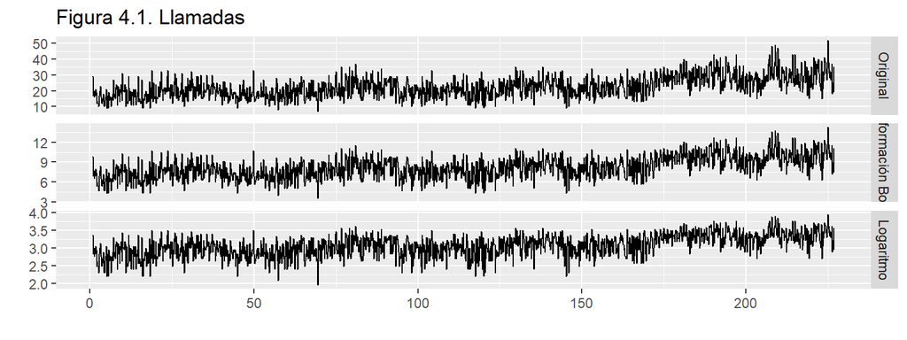

```r
wserie <-BoxCox(serie, lambda = nl)

series <- cbind("Original" = serie,
                "Transformación Box-Cox" = wserie,
                "Logaritmo" = log(serie))
autoplot(series,
         facets = TRUE,
         xlab = "",
         ylab = "",
         main = "Figura 4.1. Llamadas")
```

```r
cor(serie, wserie)
```

```
## [1] 0.9960253
```

```r
cor(serie, log(serie))
```

```
## [1] 0.9797636
```

```r
ks.test(serie, wserie)
```

```
##
##  Asymptotic two-sample Kolmogorov-Smirnov test
##
## data:  serie and wserie
## D = 0.96015, p-value < 2.2e-16
## alternative hypothesis: two-sided
```

```r
ks.test(serie, log(serie))
```

```
##
##  Asymptotic two-sample Kolmogorov-Smirnov test
##
## data:  serie and log(serie)
## D = 1, p-value < 2.2e-16
## alternative hypothesis: two-sided
```

El valor sugerido de
$$\lambda =
0.55$$
es difícil de interpretar; pero la transformación logarítmica (panel inferior) genera una serie muy similar a la transformación de Box-Cox óptica (panel medio). El cambio no es drástico pero las series transformadas tienen una varianza más constante que la serie original (primer panel).

Por tanto se considera utilizar el logaritmo de las llamadas en lugar de la serie original.

### **Diferenciaciones**

A continuación se usará la función de autocorrelación o correlograma (FAC) para determinar las diferenciaciones necesarias para alcanzar una serie estacionaria en media y ergódica.

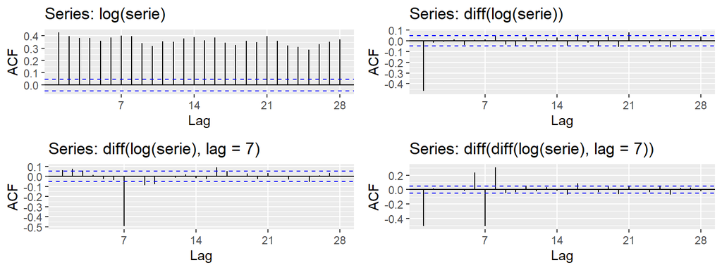

```r
# La serie temporal es diaria (frecuencia 7), entonces lag = 7
# De retardos he puesto 28 (múltiplo de 7) pero no se cuántos debería de poner la verdad
  # lag es el número máximo de retardos o rezagos que muestra en el correlograma
  # Para el lag se van a considerar múltiplos de la frecuencia de la serie (7, 14, 21, 28, etc...)
a <- ggAcf(log(serie), lag = 28)
b <- ggAcf(diff(log(serie)), lag = 28)
c <- ggAcf(diff(log(serie), lag = 7),lag = 28)
d <- ggAcf(diff(diff(log(serie), lag = 7)), lag = 28)
  # el lag de dentro es la frecuencia de la serie (7)
  # el lag de fuera es un múltiplo de éste (7*4)

(FAC<- plot_grid(a, b, c, d, ncol=2, nrow=2))
```

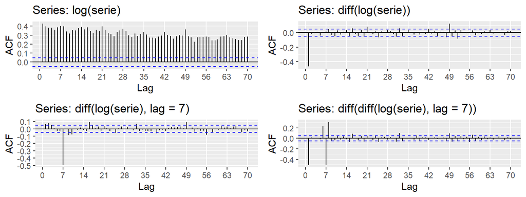

```r
# (Aumentando el número máximo de retardos hasta 70 (7*10))
a <- ggAcf(log(serie), lag = 70)
b <- ggAcf(diff(log(serie)), lag = 70)
c <- ggAcf(diff(log(serie), lag = 7),lag = 70)
d <- ggAcf(diff(diff(log(serie), lag = 7)), lag = 70)
  # el lag de dentro es la frecuencia de la serie (7)
  # el lag de fuera es un múltiplo de éste

(FAC<- plot_grid(a, b, c, d, ncol=2, nrow=2))
```

En el gráfico se muestran los coeficientes de autocorrelación en función del número de retardos. Los coeficientes de autocorrelación indican la relación entre los valores de la serie en diferentes momentos del tiempo.

El primer panel muestra que el logaritmo de la serie no es ergódica; ya que ni al cabo de 28 retardos los coeficientes de autocorrelación son nulos.

Sin embargo, la tasa de variación del logaritmo de la serie ($\Delta log(y_t)$), panel superior derecho, es estacionaria y ergódica porque muestra que sólo unos pocos coeficientes de autocorrelación son no nulos.

Por otro lado, las funciones *ndiffs* y *nsdiffs* indican que son necesarias 1 diferenciación regular y ninguna diferenciación estacional.

```r
# Identifica el número de diferenciaciones regulares
ndiffs(log(serie))
```

```
## [1] 1
```

```r
  # La función aplica el contraste de KPSS reiteradamente para identificar el número adecuado de diferenciaciones. Permite fijar el nivel de significatividad, el tipo de contraste y el tipo de tendencia determinista.
ndiffs(log(serie), alpha = 0.05, test = "kpss", type = "trend")
```

```
## [1] 1
```

```r
# Identifica el número de diferenciaciones estacionales
nsdiffs(log(serie))
```

```
## [1] 0
```

Por tanto, para obtener la estacionariedad y verificar la hipótesis de ergodicidad es necesario diferenciar sólamente en la parte regular del logaritmo de la serie. Es decir, la serie que verifica todas las hipótesis es ($\Delta log(y_t)$).

#### **Contraste KPSS**

Se realiza un contraste de raíces unitarias; la prueba de Kwiatkowski-Phillips-Schmidt-Shin. Dicha prueba usa un contraste de Multiplicadores de Lagrange para contrastar la estacionariedad de una serie en torno a una tendencia determinista, frente a la hipótesis alternativa de existencia de una raíz unitaria. Es decir la hipótesis nula es que la serie no tiene tendencia estocástica (la ausencia de raíz unitaria no es una prueba de estacionariedad, sino de estacionariedad en torno a una tendencia determinista).

**(Hay que tener en cuenta que este tipo de contraste de raíces unitarias pueden llegar a tener resultados muy paradójicos y pueden resultar poco útiles en la práctica)**

```r
# Prueba KPSS para la estacionariedad en torno a una tendencia determinista
summary(ur.kpss(serie, type = "mu", lags = "short"))
```

```
##
## #######################
## # KPSS Unit Root Test #
## #######################
##
## Test is of type: mu with 7 lags.
##
## Value of test-statistic is: 11.6276
##
## Critical value for a significance level of:
##                 10pct  5pct 2.5pct  1pct
## critical values 0.347 0.463  0.574 0.739
```

```r
# Tendencia no determinista
summary(ur.kpss(serie, type = "tau", lags = "short"))
```

```
##
## #######################
## # KPSS Unit Root Test #
## #######################
##
## Test is of type: tau with 7 lags.
##
## Value of test-statistic is: 0.9868
##
## Critical value for a significance level of:
##                 10pct  5pct 2.5pct  1pct
## critical values 0.119 0.146  0.176 0.216
```

Para un nivel de confianza del 5%, tanto si se asume la presencia de tendencia determinista o no, hay tendencia estocástica (el estadístico de contraste en ambos casos es mayor que el valor crítico). De modo que se rechaza la hipótesis nula y la serie tiene una raíz unitaria; **por tanto no es estacionaria**.

Si se repite el contraste con la serie diferenciada, esta vez para un modelo sin tendencia determinista *(type = mu)* no se rechaza la hipótesis nula, la serie diferenciada no tiene raíces unitarias y **puede considerarse estacionaria**.

```r
# Sin tendencia determinista
summary(ur.kpss((diff(log(serie), lag = 28)), type = "mu", lags = "short"))
```

```
##
## #######################
## # KPSS Unit Root Test #
## #######################
##
## Test is of type: mu with 7 lags.
##
## Value of test-statistic is: 0.0375
##
## Critical value for a significance level of:
##                 10pct  5pct 2.5pct  1pct
## critical values 0.347 0.463  0.574 0.739
```

```r
###################################
# Prueba de raíces unitarias (ADF)#
###################################
summary(ur.df(serie))
```

```
##
## ###############################################
## # Augmented Dickey-Fuller Test Unit Root Test #
## ###############################################
##
## Test regression none
##
##
## Call:
## lm(formula = z.diff ~ z.lag.1 - 1 + z.diff.lag)
##
## Residuals:
##     Min      1Q  Median      3Q     Max
## -17.567  -3.665   0.328   4.523  21.481
##
## Coefficients:
##             Estimate Std. Error t value Pr(>|t|)
## z.lag.1    -0.023497   0.006623  -3.548    4e-04 ***
## z.diff.lag -0.447014   0.022550 -19.823   <2e-16 ***
## ---
## Signif. codes:  0 '***' 0.001 '**' 0.01 '*' 0.05 '.' 0.1 ' ' 1
##
## Residual standard error: 6.07 on 1577 degrees of freedom
## Multiple R-squared:  0.2163, Adjusted R-squared:  0.2153
## F-statistic: 217.7 on 2 and 1577 DF,  p-value: < 2.2e-16
##
##
## Value of test-statistic is: -3.5476
##
## Critical values for test statistics:
##       1pct  5pct 10pct
## tau1 -2.58 -1.95 -1.62
```

```r
summary(ur.df((diff(log(serie), lag = 28))))
```

```
##
## ###############################################
## # Augmented Dickey-Fuller Test Unit Root Test #
## ###############################################
##
## Test regression none
##
##
## Call:
## lm(formula = z.diff ~ z.lag.1 - 1 + z.diff.lag)
##
## Residuals:
##      Min       1Q   Median       3Q      Max
## -1.12733 -0.21599  0.01393  0.22533  1.08423
##
## Coefficients:
##            Estimate Std. Error t value Pr(>|t|)
## z.lag.1    -0.82472    0.03410 -24.185  < 2e-16 ***
## z.diff.lag -0.09173    0.02530  -3.626 0.000297 ***
## ---
## Signif. codes:  0 '***' 0.001 '**' 0.01 '*' 0.05 '.' 0.1 ' ' 1
##
## Residual standard error: 0.3314 on 1549 degrees of freedom
## Multiple R-squared:  0.4585, Adjusted R-squared:  0.4578
## F-statistic: 655.7 on 2 and 1549 DF,  p-value: < 2.2e-16
##
##
## Value of test-statistic is: -24.1849
##
## Critical values for test statistics:
##       1pct  5pct 10pct
## tau1 -2.58 -1.95 -1.62
```

```r
# La prueba esta ni caso
```

Se grafica a continuación la serie original y la serie transformada:

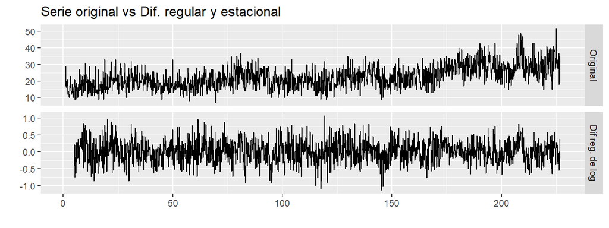

```r
series <- cbind("Original" = serie,
                "Dif reg. de log" = diff(log(serie), lag = 28))

autoplot(series, facets = TRUE,
         xlab = "",
         ylab = "",
         main = "Serie original vs Dif. regular y estacional")
```

## 4.2. Identificación

Se van a identificar los valores de *p*, *q*, *P* y *Q* del proceso ARIMA. Primero se van a analizar la FAC y la FACP, y después se utilizará la función *auto.arima*.

### **Identificación con la FAC y la FACP**

Se grafican la FAC y la función de autocorrelación parcial (FACP) de la serie transformada:

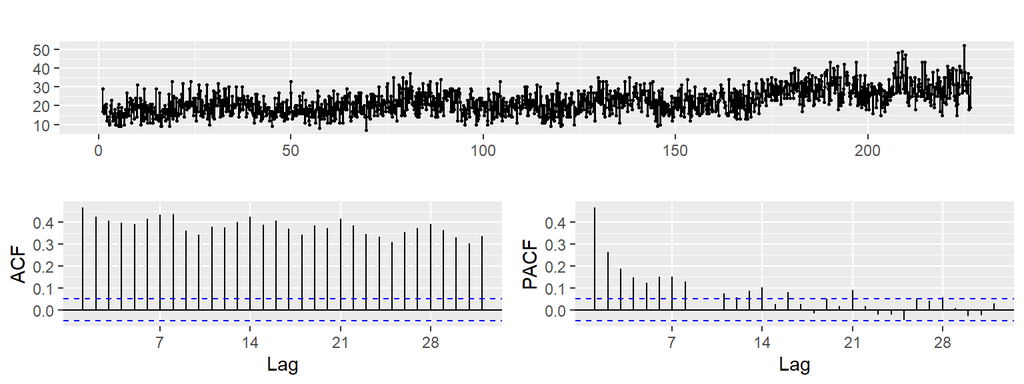

```r
ggtsdisplay(serie)
```

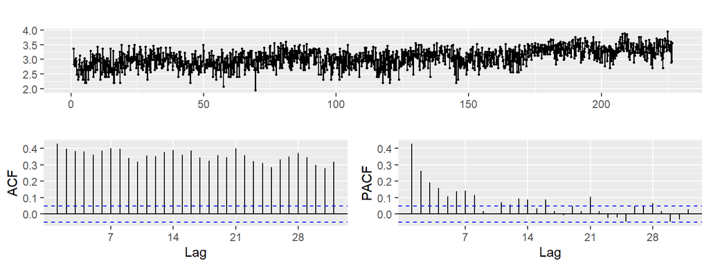

```r
ggtsdisplay(log(serie))
```

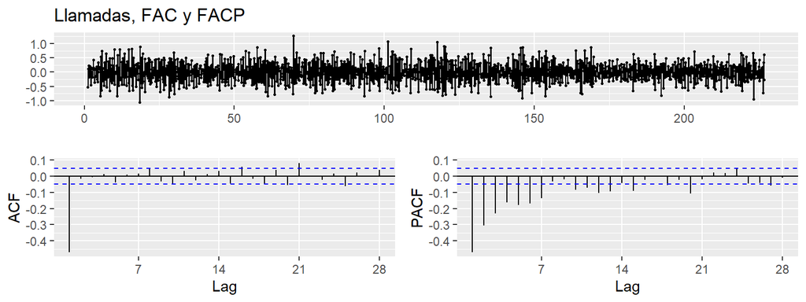

```r
ggtsdisplay(diff(log(serie)), lag = 28,
            main = "Llamadas, FAC y FACP")
```

De primeras, como la serie hay que diferenciarla una vez para que sea estacionaria, se opta por considerar
$$d =
1$$
o *serie ~ I(1)*

Respecto a identificar los valores de *p*, *q*, *P* y *Q*:

- En la parte regular, la FAC presenta un único coeficiente de autocorrelación elevado para el primer retardo y la FACP muestra un rápido decrecimiento de las autocorrelaciones parciales. Se podría interpretar un proceso regular MA(1).
- Respecto al análisis de la parte estacional; en la FAC las autocorrelaciones de los retardos múltiplos de 7 parecen encontrarse hacia arriba, pero en la FACP no está tan claro.

### **Identificación automática**

Se va a utilizar la función **auto.arima()** para localizar el mejor modelo. Se va a poner de partida que d = 1 debido a que anteriormente se ha visto que es necesario diferenciar una vez la serie (parte regular) para que sea estacionaria y ergódica.

Además se trabajará con el logaritmo de la serie para reducir la posible heterocedasticidad y ganar en interpretabilidad.

```r
auto.arima(log(serie), d = 1,
           stepwise = FALSE,
           approximation = FALSE,
           trace = TRUE)
```

```
##
##  ARIMA(0,1,0)                              : 928.0888
##  ARIMA(0,1,0)           with drift         : 930.0937
##  ARIMA(0,1,0)(0,0,1)[7]                    : 929.7411
##  ARIMA(0,1,0)(0,0,1)[7] with drift         : 931.7485
##  ARIMA(0,1,0)(0,0,2)[7]                    : 930.3267
##  ARIMA(0,1,0)(0,0,2)[7] with drift         : 932.3367
##  ARIMA(0,1,0)(1,0,0)[7]                    : 929.7186
##  ARIMA(0,1,0)(1,0,0)[7] with drift         : 931.7261
##  ARIMA(0,1,0)(1,0,1)[7]                    : Inf
##  ARIMA(0,1,0)(1,0,1)[7] with drift         : Inf
##  ARIMA(0,1,0)(1,0,2)[7]                    : Inf
##  ARIMA(0,1,0)(1,0,2)[7] with drift         : Inf
##  ARIMA(0,1,0)(2,0,0)[7]                    : 930.0192
##  ARIMA(0,1,0)(2,0,0)[7] with drift         : 932.0292
##  ARIMA(0,1,0)(2,0,1)[7]                    : Inf
##  ARIMA(0,1,0)(2,0,1)[7] with drift         : Inf
##  ARIMA(0,1,0)(2,0,2)[7]                    : Inf
##  ARIMA(0,1,0)(2,0,2)[7] with drift         : Inf
##  ARIMA(0,1,1)                              : 51.75591
##  ARIMA(0,1,1)           with drift         : 52.98054
##  ARIMA(0,1,1)(0,0,1)[7]                    : 52.06635
##  ARIMA(0,1,1)(0,0,1)[7] with drift         : 53.2724
##  ARIMA(0,1,1)(0,0,2)[7]                    : 51.56877
##  ARIMA(0,1,1)(0,0,2)[7] with drift         : 52.78148
##  ARIMA(0,1,1)(1,0,0)[7]                    : 51.90711
##  ARIMA(0,1,1)(1,0,0)[7] with drift         : 53.1111
##  ARIMA(0,1,1)(1,0,1)[7]                    : Inf
##  ARIMA(0,1,1)(1,0,1)[7] with drift         : Inf
##  ARIMA(0,1,1)(1,0,2)[7]                    : Inf
##  ARIMA(0,1,1)(1,0,2)[7] with drift         : Inf
##  ARIMA(0,1,1)(2,0,0)[7]                    : 50.43617
##  ARIMA(0,1,1)(2,0,0)[7] with drift         : 51.64813
##  ARIMA(0,1,1)(2,0,1)[7]                    : Inf
##  ARIMA(0,1,1)(2,0,1)[7] with drift         : Inf
##  ARIMA(0,1,1)(2,0,2)[7]                    : Inf
##  ARIMA(0,1,1)(2,0,2)[7] with drift         : Inf
##  ARIMA(0,1,2)                              : 46.67656
##  ARIMA(0,1,2)           with drift         : 47.70201
##  ARIMA(0,1,2)(0,0,1)[7]                    : 46.68393
```

[output cut: 142 more lines]

```
##  ARIMA(3,1,2)           with drift         : Inf
##  ARIMA(4,1,0)                              : 253.1105
##  ARIMA(4,1,0)           with drift         : 255.1229
##  ARIMA(4,1,0)(0,0,1)[7]                    : 251.438
##  ARIMA(4,1,0)(0,0,1)[7] with drift         : 253.4539
##  ARIMA(4,1,0)(1,0,0)[7]                    : 251.0029
##  ARIMA(4,1,0)(1,0,0)[7] with drift         : 253.0189
##  ARIMA(4,1,1)                              : 51.7267
##  ARIMA(4,1,1)           with drift         : 52.64759
##  ARIMA(5,1,0)                              : 203.2839
##  ARIMA(5,1,0)           with drift         : 205.296
##
##
##
##  Best model: ARIMA(1,1,1)(2,0,0)[7]
```

```
## Series: log(serie)
## ARIMA(1,1,1)(2,0,0)[7]
##
## Coefficients:
##          ar1      ma1    sar1    sar2
##       0.0781  -0.9486  0.0399  0.0502
## s.e.  0.0271   0.0099  0.0261  0.0257
##
## sigma^2 = 0.0599:  log likelihood = -17.09
## AIC=44.17   AICc=44.21   BIC=71
```

```r
  # Para hacer una búsqueda exhaustiva entre todos los posibles modelos stepwise = FALSE
  # Cálculo del AICc exacto (sin aproximar), approximation = FALSE
  # Para ver todos los modelos analizados y su correspondiente valor AICc, trace = TRUE
```

La función *auto.arima* propone una combinación de procesos regulares y estacionalres, concretamente el proceso
$$ARIMA_7(1,1,1)(2,0,0)$$
.

Antes de seguir con esta propuesta de *auto.arima*, se va a mirar la gráfica de los residuos del modelo propuesto, ya que anteriormente se identificaron valores extremos (intervención). Entonces se va a volver a solicitar la autoidentificación teniendo en cuenta variables ficticias asociadas a estos valores extremos.

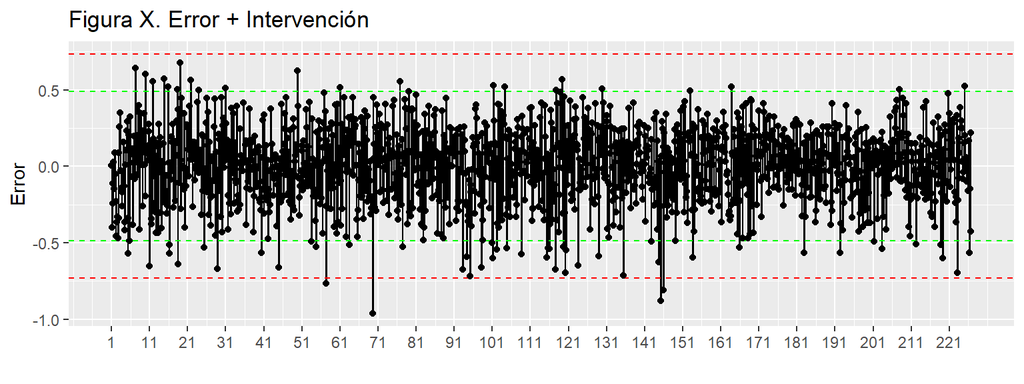

```r
arima111200 <- Arima(log(serie),
                  order = c(1, 1, 1),
                  seasonal = c(2, 0, 0))

error <- residuals(arima111200)
sderror <- sd(error)

autoplot(error, series = "error",
         colour = "black",
         xlab = "",
         ylab = "Error",
         main = "Figura X. Error + Intervención") +
  geom_hline(yintercept = c(-3, -2, 2, 3)*sderror,
             colour = c("red", "green", "green", "red"),
             lty = 2) +
  geom_point() +
  scale_x_continuous(breaks = seq(1, 226, 10))
```

```r
time(error)[abs(error) > 3*sderror]
```

```
## [1]  57.42857  69.57143 145.28571 146.00000
```

```r
time(error)[abs(error) > 2.5*sderror]
```

```
##  [1]   7.285714  11.000000  18.428571  19.000000  28.857143  45.000000
##  [7]  49.857143  57.428571  69.571429  93.285714  95.142857  98.142857
## [13] 117.571429 120.142857 123.571429 135.428571 144.714286 145.285714
## [19] 146.000000 223.142857
```

Se identifican cuatro valores extremos que superan las tres desviaciontes típicas. Pero si se tienen en cuenta aquellos que superan las dos con cinco desviaciones típicas se tienen un total de 20:

| **Valor** | **Día, semana** | **Fecha** | **Desv. tip.** |
| --- | --- | --- | --- |
| 7.285714 | Miércoles, 7 | 2018-02-14 | 2.6 |
| 11.000000 | Lunes, 11 | 2018-03-12 | 2.6 |
| 18.428571 | Jueves, 18 | 2018-05-03 | 2.6 |
| 19.000000 | Lunes, 19 | 2018-05-07 | 2.7 |
| 28.857143 | Domingo, 28 | 2018-07-15 | 2.7 |
| 45.000000 | Lunes, 45 | 2018-11-05 | 2.7 |
| 49.857143 | Domingo, 49 | 2018-12-09 | 2.5 |
| 57.428571 | Jueves, 57 | 2019-01-31 | 3 |
| 69.571429 | Viernes, 69 | 2019-04-26 | 3 |
| 93.285714 | Miércoles, 93 | 2019-10-09 | 2.7 |
| 95.142857 | Martes, 95 | 2019-10-22 | 2.9 |
| 98.142857 | Martes, 98 | 2019-11-12 | 2.7 |
| 117.571429 | Viernes, 117 | 2020-03-27 | 2.7 |
| 120.142857 | Martes, 120 | 2020-04-14 | 2.8 |
| 123.571429 | Viernes, 123 | 2020-05-08 | 2.6 |
| 135.428571 | Jueves, 135 | 2020-07-30 | 2.9 |
| 144.714286 | Sábado, 144 | 2020-10-03 | 2.5 |
| 145.285714 | Miércoles, 145 | 2020-10-07 | 3 |
| 146.000000 | Lunes, 146 | 2020-10-12 | 3 |
| 223.142857 | Martes, 223 | 2022-04-05 | 2.8 |

Para poder relacionar las fechas correspondientes a dichos valores se han buscado acontecimientos y festivos nacionales, así como locales y regionales de la Comunidad Valenciana. Muy pocas fechas coinciden o se han podido relacionar.

La fecha **2018-02-14** coincide con **San Valentín** y **Miércoles de ceniza**; observando el residuo en la figura X se puede apreciar que dicha fecha (miércoles de la semana 7) se encuentra por encima de las 2.6 desviaciones típicas en la parte superior; por tanto en aquella fecha tuvo lugar un mayor número de llamadas de intento de suicidio de lo normal.

En **2019-10-09** fue el día de la Comunitat Valenciana y hubieron menos de lo esperado (intervención por debajo sobrepasando las 2.7 desviaciones típicas).

```r
# Cómo R guarda el fechado. Siendo una serie diaria.
  # x = semana
  # Lunes -> x
  # Martes -> x + 1/7 = x + 0.1428571
  # Miércoles -> x + 2/7 = x + 0.2857143
  # Jueves -> x + 3/7 = x + 0.4285714
  # Viernes -> x + 4/7 = x + 0.5714286
  # Sábado -> x + 5/7 = x + 0.7142857
  # Domingo -> x + 6/7 = x + 0.8571429

library(seasonal)

## Valores extremos que superar las 3 desv. típ.

d57 <- 1*(cycle(error) == 4 & trunc(time(error)) == 57)
  # Jueves de la semana 57; 2019-01-31; 3 desv.tip.

d69 <- 1*(cycle(error) == 5 & trunc(time(error)) == 69)
  # Viernes de la semana 69; 2019-04-26; 3 desv.tip.

# Nuestra Señora del Rosario
d145 <- 1*(cycle(error) == 3 & trunc(time(error)) == 145)
  # Miércoles de la semana 145; 2020-10-07; 3 desv.tip.

# Fiesta Nacional de España
d146 <- 1*(cycle(error) == 1 & trunc(time(error)) == 146)
  # Lunes de la semana 146; 2020-10-12; 3 desv.tip.


## Valores de intervención detectados o relacionados con festivos:
  # San Valentín y Miércoles de ceniza
d7 <- 1*(cycle(error) == 3 & trunc(time(error)) == 7)
  # Miércoles de la semana 7; 2018-02-14; 2.6 desv.tip.

# Día de la Comunidad Valenciana (festivo regional)
d93 <- 1*(cycle(error) == 3 & trunc(time(error)) == 93)
  # Miércoles de la semana 93; 2019-10-09; 2.7 desv.tip.


## Valores de intervención considerados prácticamente extremos
  ## 2.9 desv.tip

d95 <- 1*(cycle(error) == 2 & trunc(time(error)) == 95)
  # Martes de la semana 95; 2019-10-22

d135 <- 1*(cycle(error) == 4 & trunc(time(error)) == 135)
  # Jueves de la semana 135; 2020-07-30

# Al final tengo en cuenta solamente los cuatro valores que superan las 3 desviaciones típicas y el de San Valentín por la naturaleza de los datos
auto.arima(log(serie), d = 1,
           stepwise = FALSE,
           approximation = FALSE,
           trace = TRUE,
           xreg = cbind(d7, d57, d69, d145, d146))
```

```
##
##  Regression with ARIMA(0,1,0)           errors : 875.2491
##  Regression with ARIMA(0,1,0)           errors : 877.2667
##  Regression with ARIMA(0,1,0)(0,0,1)[7] errors : 876.8702
##  Regression with ARIMA(0,1,0)(0,0,1)[7] errors : 878.8904
##  Regression with ARIMA(0,1,0)(0,0,2)[7] errors : 876.7106
##  Regression with ARIMA(0,1,0)(0,0,2)[7] errors : 878.7334
##  Regression with ARIMA(0,1,0)(1,0,0)[7] errors : 876.8388
##  Regression with ARIMA(0,1,0)(1,0,0)[7] errors : 878.859
##  Regression with ARIMA(0,1,0)(1,0,1)[7] errors : Inf
##  Regression with ARIMA(0,1,0)(1,0,1)[7] errors : Inf
##  Regression with ARIMA(0,1,0)(1,0,2)[7] errors : Inf
##  Regression with ARIMA(0,1,0)(1,0,2)[7] errors : Inf
##  Regression with ARIMA(0,1,0)(2,0,0)[7] errors : 876.3003
##  Regression with ARIMA(0,1,0)(2,0,0)[7] errors : 878.3231
##  Regression with ARIMA(0,1,0)(2,0,1)[7] errors : Inf
##  Regression with ARIMA(0,1,0)(2,0,1)[7] errors : Inf
##  Regression with ARIMA(0,1,0)(2,0,2)[7] errors : Inf
##  Regression with ARIMA(0,1,0)(2,0,2)[7] errors : Inf
##  Regression with ARIMA(0,1,1)           errors : 6.952447
##  Regression with ARIMA(0,1,1)           errors : 8.147759
##  Regression with ARIMA(0,1,1)(0,0,1)[7] errors : 7.719512
##  Regression with ARIMA(0,1,1)(0,0,1)[7] errors : 8.898813
##  Regression with ARIMA(0,1,1)(0,0,2)[7] errors : 6.215291
##  Regression with ARIMA(0,1,1)(0,0,2)[7] errors : 7.402859
##  Regression with ARIMA(0,1,1)(1,0,0)[7] errors : 7.58249
##  Regression with ARIMA(0,1,1)(1,0,0)[7] errors : 8.759695
##  Regression with ARIMA(0,1,1)(1,0,1)[7] errors : Inf
##  Regression with ARIMA(0,1,1)(1,0,1)[7] errors : Inf
##  Regression with ARIMA(0,1,1)(1,0,2)[7] errors : Inf
##  Regression with ARIMA(0,1,1)(1,0,2)[7] errors : Inf
##  Regression with ARIMA(0,1,1)(2,0,0)[7] errors : 5.050374
##  Regression with ARIMA(0,1,1)(2,0,0)[7] errors : 6.237817
##  Regression with ARIMA(0,1,1)(2,0,1)[7] errors : Inf
##  Regression with ARIMA(0,1,1)(2,0,1)[7] errors : Inf
##  Regression with ARIMA(0,1,1)(2,0,2)[7] errors : Inf
##  Regression with ARIMA(0,1,1)(2,0,2)[7] errors : Inf
##  Regression with ARIMA(0,1,2)           errors : 0.9620526
##  Regression with ARIMA(0,1,2)           errors : 1.935442
##  Regression with ARIMA(0,1,2)(0,0,1)[7] errors : 1.396001
```

[output cut: 142 more lines]

```
##  Regression with ARIMA(3,1,2)           errors : 6.321338
##  Regression with ARIMA(4,1,0)           errors : 206.5597
##  Regression with ARIMA(4,1,0)           errors : 208.5849
##  Regression with ARIMA(4,1,0)(0,0,1)[7] errors : 205.5464
##  Regression with ARIMA(4,1,0)(0,0,1)[7] errors : 207.5751
##  Regression with ARIMA(4,1,0)(1,0,0)[7] errors : 205.1285
##  Regression with ARIMA(4,1,0)(1,0,0)[7] errors : 207.1573
##  Regression with ARIMA(4,1,1)           errors : 5.379874
##  Regression with ARIMA(4,1,1)           errors : 6.2044
##  Regression with ARIMA(5,1,0)           errors : 160.9554
##  Regression with ARIMA(5,1,0)           errors : 162.9804
##
##
##
##  Best model: Regression with ARIMA(1,1,2)(2,0,0)[7] errors
```

```
## Series: log(serie)
## Regression with ARIMA(1,1,2)(2,0,0)[7] errors
##
## Coefficients:
##          ar1      ma1     ma2    sar1    sar2      d7      d57      d69
##       0.5243  -1.3940  0.4176  0.0455  0.0609  0.5310  -0.7533  -0.9845
## s.e.  0.2036   0.2128  0.2014  0.0264  0.0260  0.2349   0.2350   0.2352
##          d145     d146
##       -0.8646  -0.8196
## s.e.   0.2348   0.2354
##
## sigma^2 = 0.05792:  log likelihood = 12.44
## AIC=-2.87   AICc=-2.7   BIC=56.15
```

Teniendo en cuenta los valores extremos detectados como variables de intervención, *auto.arima* propone el modelo
$$ARIMA_7(1,1,2)(2,0,0)$$
.

(No puedo usar la función *seas* de la librería *seasonal* porque mi serie no es mensual ni trimestral; es diaria).

Teniendo en cuenta estos análisis se concluye que la identificación de partida es
$$ARIMA_7(1,1,2)(2,0,0) +
AI$$
,

donde *AI* recoge todas las variables de intervención.

Se va a estimar el modelo identificado incluyendo las variables de intervención para volver a analizar si quedan valores atípicos.

```r
arima112200 <- Arima(log(serie),
                  order = c(1, 1, 2),
                  seasonal = list(order = c(2, 0, 0), period = 7),
           xreg = cbind(d7, d57, d69, d145, d146))

arima112200
```

```
## Series: log(serie)
## Regression with ARIMA(1,1,2)(2,0,0)[7] errors
##
## Coefficients:
##          ar1      ma1     ma2    sar1    sar2      d7      d57      d69
##       0.5243  -1.3940  0.4176  0.0455  0.0609  0.5310  -0.7533  -0.9845
## s.e.  0.2036   0.2128  0.2014  0.0264  0.0260  0.2349   0.2350   0.2352
##          d145     d146
##       -0.8646  -0.8196
## s.e.   0.2348   0.2354
##
## sigma^2 = 0.05792:  log likelihood = 12.44
## AIC=-2.87   AICc=-2.7   BIC=56.15
```

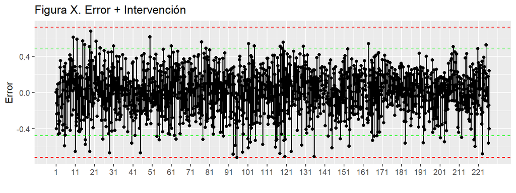

```r
error <- residuals(arima112200)
sderror <- sd(error)

autoplot(error, series = "error",
         colour = "black",
         xlab = "",
         ylab = "Error",
         main = "Figura X. Error + Intervención") +
  geom_hline(yintercept = c(-3, -2, 2, 3)*sderror,
             colour = c("red", "green", "green", "red"),
             lty = 2) +
  geom_point() +
  scale_x_continuous(breaks = seq(1, 226, 10))
```

```r
time(error)[abs(error) > 3*sderror]
```

```
## numeric(0)
```

El modelo
$$ARIMA_7(1,1,2)(2,0,0) +
AI$$
, al tener en cuenta las variables de intervención, parece ajustar mejor; concretamente si se compara el AIC, con dicho modelo disminuye. Así como también se puede apreciar en la figura X que no hay más errores extremos que superen las tres desviaciones típicas a tener en cuenta.

## 4.3. Validación

### Variables significativas

Asumiendo que ya no hay más valores extremos, se va a mirar si todos los coeficientes del modelo son significativos aplicando la prueba de Wald.

```r
library(aod) # para la prueba de Wald
# wald.test(b = coef(arima111200), Sigma = vcov(arima111200), Terms = 1)
# wald.test(b = coef(arima111200), Sigma = vcov(arima111200), Terms = 2)
# wald.test(b = coef(arima111200), Sigma = vcov(arima111200), Terms = 3)
# wald.test(b = coef(arima111200), Sigma = vcov(arima111200), Terms = 4)
# wald.test(b = coef(arima111200), Sigma = vcov(arima111200), Terms = 5)
# wald.test(b = coef(arima111200), Sigma = vcov(arima111200), Terms = 6)
# wald.test(b = coef(arima111200), Sigma = vcov(arima111200), Terms = 7)
# wald.test(b = coef(arima111200), Sigma = vcov(arima111200), Terms = 8)

prueba.Wald <- max(nchar(names(coef(arima112200)))) + 2
for (i in 1:length(coef(arima112200))) {
  wt <- wald.test(b = coef(arima112200),
                  Sigma = vcov(arima112200),
                  Terms = i)
  cat("\nCoeficiente: ",
      format(names(coef(arima112200))[i],
             width = prueba.Wald),
      "valor de p: ",
      formatC(wt$result$chi2[3],
              digits = 4, format = "f"))
}
```

```
##
## Coeficiente:  ar1    valor de p:  0.0100
## Coeficiente:  ma1    valor de p:  0.0000
## Coeficiente:  ma2    valor de p:  0.0381
## Coeficiente:  sar1   valor de p:  0.0844
## Coeficiente:  sar2   valor de p:  0.0190
## Coeficiente:  d7     valor de p:  0.0238
## Coeficiente:  d57    valor de p:  0.0013
## Coeficiente:  d69    valor de p:  0.0000
## Coeficiente:  d145   valor de p:  0.0002
## Coeficiente:  d146   valor de p:  0.0005
```

Parece no ser significativo el coeficiente de sar1

### Incorrelación, Homocedasticidad y Normalidad

Se ve si el residuo es ruido blanco:

**Incorrelación**

$$H_0: \rho_1 = ... = \rho_k =
0$$

**Homocedasticidad**

La hipótesis nula seria que las primeras *k* autocorrelaciones estimadas sobre el cuadrado del residuo son cero.

```r
error <- residuals(arima112200)

for (i in 2:7) { # Incorrelación
  inc <- Box.test(error, lag = i, type = "Ljung-Box")
  cat("\np-valor: ",
      formatC(inc$p.value,
              digits = 4, format = "f"))
}
```

```
##
## p-valor:  0.9981
## p-valor:  0.9999
## p-valor:  0.9748
## p-valor:  0.8973
## p-valor:  0.9415
## p-valor:  0.9721
```

```r
for (i in 2:7) { # Homocedasticidad
  homoc <- Box.test(error^2, lag = i, type = "Ljung-Box")
  cat("\np-valor: ",
      formatC(homoc$p.value,
              digits = 4, format = "f"))
}
```

```
##
## p-valor:  0.9082
## p-valor:  0.6795
## p-valor:  0.8220
## p-valor:  0.6216
## p-valor:  0.2384
## p-valor:  0.2576
```

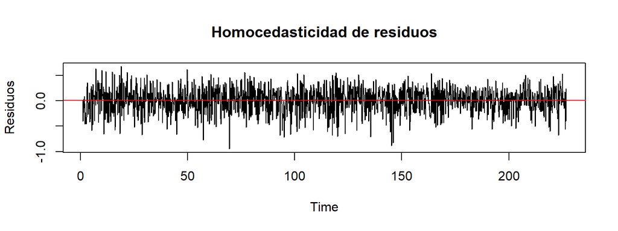

```r
# Para mirarlo gráficamente la homocedasticidad
  # Se ajusta el modelo y se guardan los residuos
    # fit <- arima(serie, order = c(p, d, q), seasonal = c(P, D, Q), lambda = lambda)

fit <- arima(log(serie), order = c(1, 1, 2), seasonal = c(2, 0, 0))

residuos <- residuals(fit)

  # Se calcula la media y la varianza de los residuos
media_residuos <- mean(residuos)
var_residuos <- var(residuos)

  # Se grafica los residuos en función del tiempo (agregando una línea horizontal en la media de los residuos)
plot(residuos, ylab = "Residuos", main = "Homocedasticidad de residuos")
abline(h = media_residuos, col = "red")
```

```r
library(tseries) # libreria para el test de Jarque Bera

jarque.bera.test(error) # Normalidad
```

```
##
##  Jarque Bera Test
##
## data:  error
## X-squared = 22.74, df = 2, p-value = 1.153e-05
```

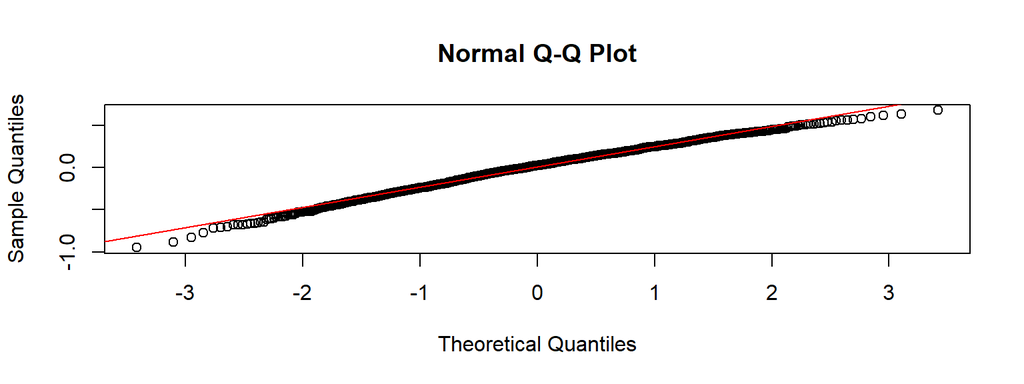

```r
# Gráficos de los residuos
qqnorm(residuos)
qqline(residuos, col = "red")
```

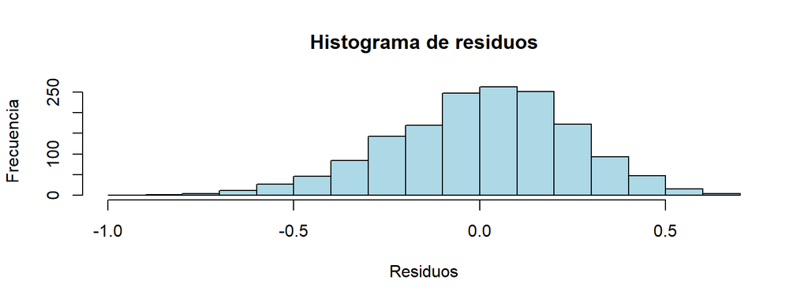

```r
hist(residuos, breaks = "Sturges",
     col = "lightblue", border = "black",
     xlab = "Residuos", ylab = "Frecuencia",
     main = "Histograma de residuos")
```

Las hipótesis de incorrelación y homocedasticidad se aceptan (incluso para otros valores de *k* razonables). Sin embargo, la hipótesis de normalidad se rechaza (p-valor significativo < 0.05); aunque esto no impide usar el modelo ARIMA para predecir. Y por la Ley de los Grandes Números se considera que el tamaño muestral es grande y lo suficientemente robusto como para que no sea un problema.

### Medidas de error

```r
arima112200
```

```
## Series: log(serie)
## Regression with ARIMA(1,1,2)(2,0,0)[7] errors
##
## Coefficients:
##          ar1      ma1     ma2    sar1    sar2      d7      d57      d69
##       0.5243  -1.3940  0.4176  0.0455  0.0609  0.5310  -0.7533  -0.9845
## s.e.  0.2036   0.2128  0.2014  0.0264  0.0260  0.2349   0.2350   0.2352
##          d145     d146
##       -0.8646  -0.8196
## s.e.   0.2348   0.2354
##
## sigma^2 = 0.05792:  log likelihood = 12.44
## AIC=-2.87   AICc=-2.7   BIC=56.15
```

```r
accuracy(arima112200)
```

```
##                       ME      RMSE       MAE        MPE     MAPE      MASE
## Training set 0.005423537 0.2398362 0.1917331 -0.4632187 6.437865 0.7273708
##                     ACF1
## Training set 0.001157136
```

```r
round(accuracy(arima112200),2)
```

```
##                ME RMSE  MAE   MPE MAPE MASE ACF1
## Training set 0.01 0.24 0.19 -0.46 6.44 0.73    0
```

### Predicción

```r
serieARIMA.prediccion <- forecast(arima112200,
                          h = 35, # 35 semanas
                          level = 95,
                       xreg = cbind(rep(0,35), rep(0,35), rep(0,35), rep(0,35), rep(0,35))) # matriz para variables de intervención

serieARIMA.prediccion
```

```
##          Point Forecast    Lo 95    Hi 95
## 226.8571       3.376193 2.904479 3.847907
## 227.0000       3.411547 2.935842 3.887252
## 227.1429       3.402162 2.924481 3.879843
## 227.2857       3.357834 2.878950 3.836717
## 227.4286       3.377055 2.897297 3.856813
## 227.5714       3.354794 2.874313 3.835274
## 227.7143       3.390864 2.909735 3.871993
## 227.8571       3.372425 2.889128 3.855722
## 228.0000       3.382485 2.898452 3.866517
## 228.1429       3.392854 2.908141 3.877566
## 228.2857       3.346951 2.861588 3.832314
## 228.4286       3.367843 2.881845 3.853841
## 228.5714       3.350114 2.863489 3.836740
## 228.7143       3.388973 2.901725 3.876220
## 228.8571       3.377220 2.886957 3.867483
## 229.0000       3.379832 2.888746 3.870919
## 229.1429       3.379733 2.887889 3.871577
## 229.2857       3.374943 2.882376 3.867510
## 229.4286       3.377065 2.883794 3.870336
## 229.5714       3.374902 2.880935 3.868868
## 229.7143       3.378868 2.884212 3.873524
## 229.8571       3.377210 2.881721 3.872699
## 230.0000       3.377942 2.881751 3.874133
## 230.1429       3.378569 2.881683 3.875455
## 230.2857       3.375554 2.877978 3.873131
## 230.4286       3.376924 2.878659 3.875189
## 230.5714       3.375745 2.876794 3.874696
## 230.7143       3.378293 2.878657 3.877929
## 230.8571       3.377502 2.877077 3.877926
## 231.0000       3.377694 2.876574 3.878814
## 231.1429       3.377716 2.875905 3.879528
## 231.2857       3.377287 2.874788 3.879787
## 231.4286       3.377479 2.874294 3.880664
## 231.5714       3.377294 2.873424 3.881163
## 231.7143       3.377651 2.873099 3.882204
```

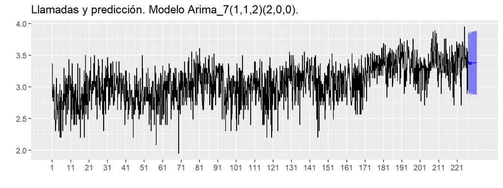

```r
autoplot(serieARIMA.prediccion,
         xlab = "",
         ylab = "",
         main = "Llamadas y predicción. Modelo Arima_7(1,1,2)(2,0,0).") +
  scale_x_continuous(breaks = seq(1, 226, 10))
```

### Comparación entre modelos

```r
k <- 630
h <- 21
TT <- length(serie)
s <- TT - k - h

mapeArima <- matrix(NA, s + 1, h)
mapeArima2 <- matrix(NA, s + 1, h)

X <- cbind(d7, d57, d69, d145, d146)

for (i in 0:s) {
  train.set <- subset(serie, start = i + 1, end = i + k)
  test.set <-  subset(serie, start = i + k + 1, end = i + k + h)

  # Opción 1. ARIMA_7(1, 1, 2)(2, 0, 0)

  fit <- try(Arima(train.set,
                   order = c(1, 1, 2),
                   seasonal = list(order = c(2, 0, 0), period = 7)),
             silent = TRUE)

  if (!is.element("try-error", class(fit))) {
    fcast <- forecast(fit, h = h)
    mapeArima[i + 1, ] <- 100 * abs(test.set - fcast$mean) / test.set
  }

  # Opción 2. ARIMA_7(1, 1, 2)(2, 0, 0) + AI
  X.train <- X[(i + 1):(i + k),]
  hay <- colSums(X.train)
  X.train <- X.train[, hay > 0]

  X.test <- X[(i + k + 1):(i + k + h),]
  X.test <- X.test[, hay > 0]

  fit <- try(Arima(train.set,
                   order = c(1, 1, 2),
                   seasonal = list(order = c(2, 0, 0), period = 7),
                   xreg = X.train), silent = TRUE)

  if (!is.element("try-error", class(fit))) {
    fcast <- forecast(fit, h = h, xreg = X.test)
    mapeArima2[i + 1, ] <- 100 * abs(test.set - fcast$mean) / test.set
  }

}

errorArima <- colMeans(mapeArima, na.rm = TRUE)
errorArima2 <- colMeans(mapeArima2, na.rm = TRUE)

round(errorAlisado1, 2)
```

```
##  [1] 19.80 19.92 20.02 20.13 20.18 20.14 20.13 20.12 20.23 20.23 20.20 20.23
## [13] 20.18 20.24 20.35 20.36 20.44 20.49 20.44 20.56 20.67
```

```r
round(errorArima, 2)
```

```
##  [1] 20.31 20.45 20.69 20.57 20.70 20.28 20.54 20.52 20.59 20.45 20.57 20.55
## [13] 20.32 20.68 20.63 20.86 20.95 20.92 21.10 21.06 21.00
```

```r
round(errorArima2, 2)
```

```
##  [1] 20.31 20.36 20.61 20.61 20.68 20.56 20.64 20.71 20.49 20.59 20.71 20.73
## [13] 20.69 20.86 20.81 20.69 20.77 21.08 21.04 21.03 21.15
```

[figure not shown]

```r
ggplot() +
  geom_line(aes(x = 1:21, y = errorAlisado1, colour = "Alisado - ETS(M,N,A)")) +
  geom_line(aes(x = 1:21, y = errorArima, colour = "ARIMA_7(1, 1, 2)(2, 0, 0)"))  +
  geom_line(aes(x = 1:21, y = errorArima2, colour = "ARIMA_7(1, 1, 2)(2, 0, 0) + AI"))  +
  ggtitle("Error de predicción (MAPE) según horizonte temporal y enfoque") +
  xlab("Horizonte temporal de predicción") +
  ylab("%") +
  scale_x_continuous(breaks= 1:21) + # error hasta 21 semanas
  scale_y_continuous(breaks = seq(1.5, 4, .5)) + # escala eje y
  guides(colour = guide_legend(title = "Modelos")) # título leyenda
```